# A3: SPL Library Checkouts

Flora Lee

2023-02-27

### Introduction

In this assignment, I chose to focus on the book related to the author George Orwell. When I was young, I read 1984 and Animal Farm and was impressed by these two books, and I had an interest in analyzing my data with this author. As the data is provided by Seattle Public Library, the dataset includes columns like ‘UsageClass’, which means whether it is a physical or digital form of a book, ‘materialType’, which denotes if it is categorized as a book, ebook, sound disc, or video disc, and other columns. In this report, I’m focusing on the average number of checkouts in this dataset, which year had the most/least checkouts, which year had the most/least checkouts for ebooks, how the number of print book checkouts is changed over time, and how many new checkouts there were when the most checkouts occurred.

### Summary Information

The dataset I chose to analyze is close to the author George Orwell, and the average number of checkouts for this dataset is **5.4324843**. The number of the most checkout in 2020 in this dataset is **228**. The title of the most checkouts in 2020 in this dataset is **1984 (Unabridged)**.

Also, the number of the most checkouts in 2020 for “ebook” in this dataset is **82**. The title of the most checkouts in 2020 for “ebook” in this dataset is **1984**.

When looking at how the number of print book checkouts has changed over time, I compared the total number of checkouts now and five years ago. For the total checkout now, it was **451**. On the other hand, the total checkout in 2018 is **3602**. So, the difference in the number of checkouts between 2018 and 2023 is **3151**. Finally, when looking at the chances of how many new checkouts there were when the most checkouts occurred, it is **223**.

### The Dataset

- Who collected/published the data?  
  This dataset was published by the Seattle Public Library.
- What are the parameters of the data (dates, number of checkouts, kinds of books, etc.)? This dataset has columns like ‘UsageClass’, which means whether it is a physical or digital form of a book, ‘MaterialType’, which denotes if it is categorized as a book, ebook, sound disc, or video disc, and ‘CheckoutYear’, ‘CheckoutMonth’, ‘Checkouts’, ‘Creator’, etc. The parameters include when the checkout occurred for this record and the number of times the title was checked out.
- How was the data collected or generated? The dataset was first provided by the Seattle Public Library, and from the SPL Open Data portal, I chose to use my own datasets by filtering ‘George Orwell’ author. The dataset made for my own use indicates that any column includes ‘George Orwell’ such as either in the ‘Creator’ column or in the ‘Title’ column.
- Why was the data collected?  
  The purpose of the data collected was to analyze how many checkouts there are and how the number of the checkouts has changed over time.
- What, if any, ethical questions do you need to consider when working with this data?  
  Since this is collected and provided by the Seattle Public Library, I’m not sure what ethical issue there might have arisen as it is a public source. However, we can’t assume that the dataset is 100% accurate and true. In other words, there might still be the possibility of fake information and data.
- What are possible limitations or problems with this data? (at least 200 words) In this dataset, I realized that the ‘CheckoutYear’ is widely distributed with variances in one year. For instance, if I set 2016 as a singular criterion, there are many 2016 checkout years and various titles, material types, usage classes, subjects, and publishers. It indicates that if I want to compare the number of checkouts for each year and how the number of checkouts has changed over time, which means trends of checkouts, I should either make a new column for the total of checkouts for one specific year. For the checkout year 2016, I might need to use mutate, group_by, and summarize functions to get the total of checkouts in the entire 2016.

The other problem I see with this dataset is that there are the same title names but they are named differently. This is quite similar to the first issue I mentioned. The dataset I’m working on is that I made on my own from the general dataset from SPL and searched dataset with the author George Orwell’. However, in this dataset, even though they are the same book and have the same title with subtle differences such as differences in publishing and editing version, there are many titles for the same title. For instance, the book title 1984 is also named as ‘Nineteen eighty-four / a novel by George Orwell’ or ‘1984 (Unabridged)’.

### First Chart: Trends Over Time

#To see the trend of books’ checkouts, how has the number of checkouts changed over time?

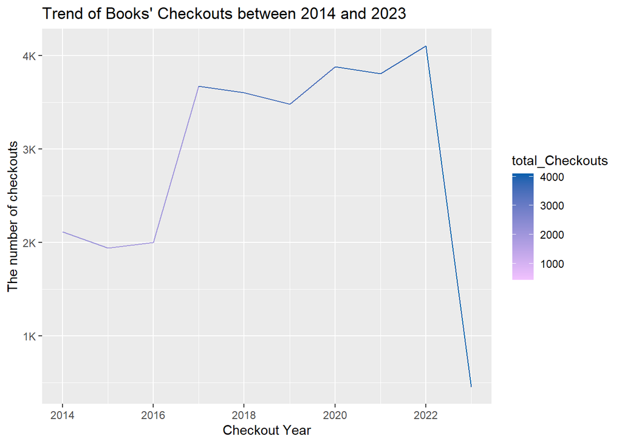

### Second Chart: Trends Over Time

#To see the trend of ’EBOOK’s checkouts, how has the number of checkouts changed over time?

Similarly, in the second chart, I included this line plot chart to see the trend of the ’Ebook’s checkouts over time. This time, I brought the Ebook to see how it is different from the books. Since this is to view the trend of a variable over time, I thought this line plot would be a great way to view the changes over time as well. From 2014 to 2023, there is a checkout year on the x axis, and the number of checkouts on the y axis. In the plot, it seems from 2017, the checkouts have been increasing relatively far more than the previous three years including 2014, 2015, and 2016 like the previous line chart for just books. One difference compared to the first chart is there is a more gradually increasing trend from 2017 to 2021. But in 2022, there will be a slight decrease from the previous year. Likewise in the first chart, as there might be few months in 2023 yet compared to other checkout years that have the entire twelve months, in 2023 the line is shown as a very low result.

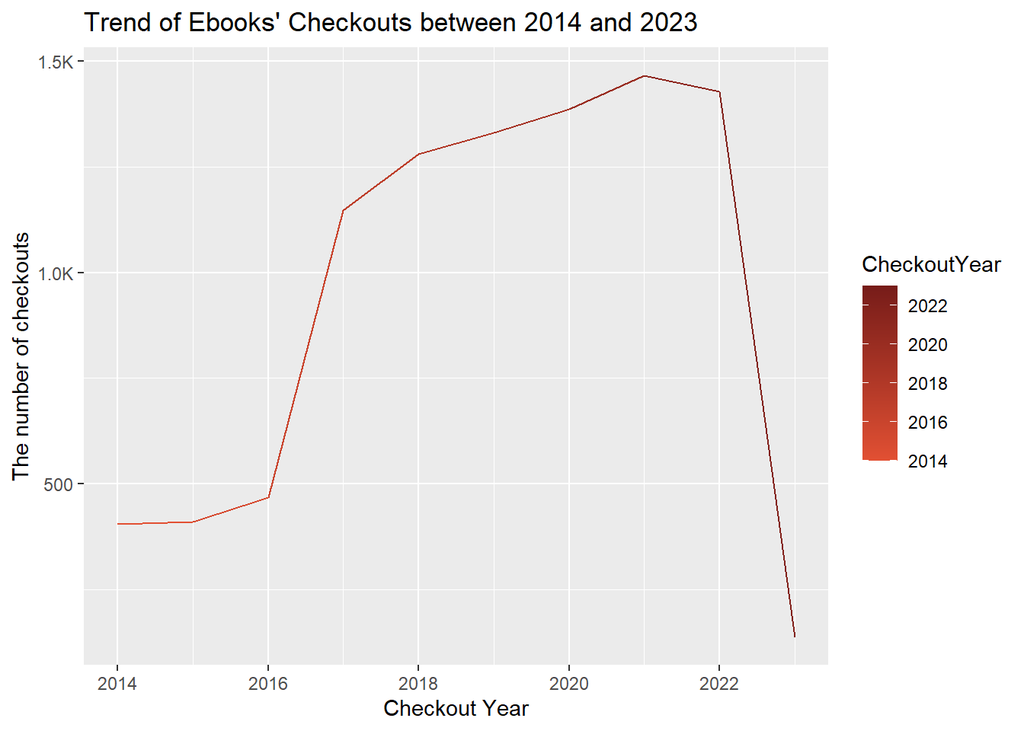

### Third Chart

#To see what the books that the number of checkouts is over 80 are in 2022, make a bar chart.

For the last chart, I have a bar chart to see what the books that the number of checkouts is over 80 are in 2022. By plotting seven book titles that have had more than 80 checkouts, I was able to make a bar chart to see how the books are distributed. From the bar chart, it seems there are three ‘1984’, another three ‘Animal Farm’, and one ‘Orwell’s roses’. Total seven books are there and the most checkouts among these are from ‘1984’.

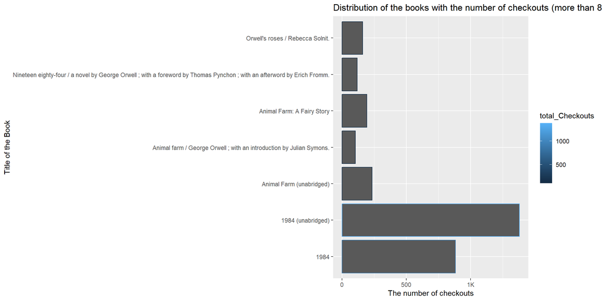